# Data Challenge 5: Clustering Tissue Samples

Ziyan Hu

Due 5:59pm on Nov 17, 2023

Link to the github: https://github.com/freyahu2000/DataChallenge5

```r
library(tidyverse)
```

## Problem 1

Use the gene expression data in `Ch10Ex11.csv` that is provided for you on Canvas. This is gene expression data that consists of 40 tissue samples with measurements on 1,000 genes. The first 20 samples are from healthy patients, while the second 20 are from a diseased group.

- Load the data – note that there is no header so you will need to read this in without one. Note that rows in this dataset represent genes and columns subjects. You will need to transpose the data using the function `t()` before you cluster (as we would like to cluster subjects).
- Scale the data.
- Using the code from the lecture notes and the `kmeans` function in R, produce the associated elbow plot (i.e., a plot of within-cluster sum of squares vs. cluster size). You can use 1 through 15 for your k values. Given your plot, what is the appropriate number of clusters for the data? Why?
- Cluster the scaled data using the `kmeans` function in R. Try this with the number of clusters you concluded in Step 3 and 50 iterations.
- Summarize the results in a contingency table. A contingency table is a tabular representation of categorical data that typically shows the frequency of the combinations of the two variables (i.e., an m by n table). Here we would like to show a table of our clustering versus the true disease status of the subjects. Create a variable of the disease status for the 40 tissue samples. Use the clustering that you obtained in the previous step. Create a table of the two variables using `table()`. Comment on what you observe.
- Don’t forget to set a seed number before running any function that introduces randomness!

### Solution

**1.1**

```r
# load the gene expression data
gene <- read_csv("Ch10Ex11.csv",col_names = FALSE)
# transpose the data
gene <- t(gene)
```

**1.2**

```r
# transpose and scale the data
scaled_gene<- scale(gene)
```

**1.3**

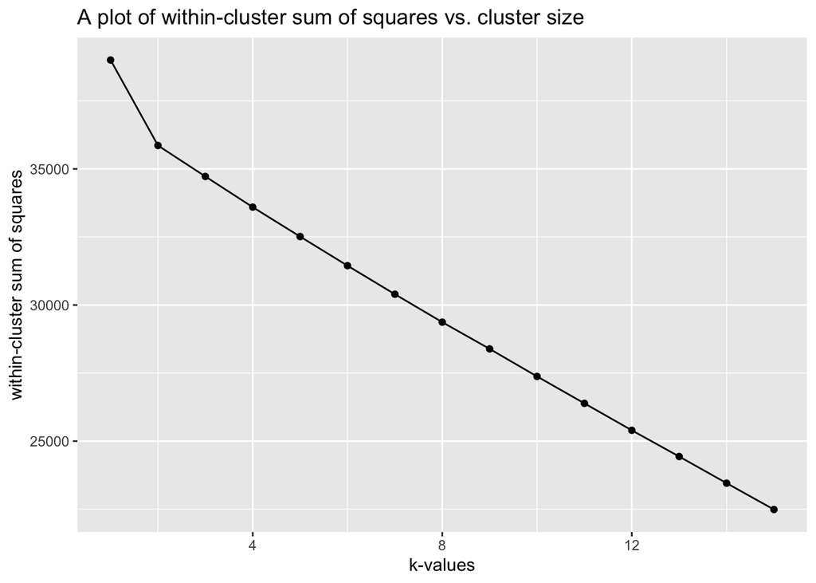

```r
# calculate within-cluster sum of squares for different k values
set.seed(123)
wss <- function(k, data) {
  kmeans(data, k, nstart = 50)$tot.withinss
}

# define a range of k values to assess
k_values <- 1:15

# map the wss function across the range of k values for 'scaled_gene' data
wss_values <- map_dbl(k_values, wss, data = scaled_gene)

# create a tibble to store WCSS and corresponding k values
wss_values <- tibble(wss = wss_values, k = k_values)

# plot WCSS against the number of clusters k
g <- ggplot(wss_values, aes(x = k, y = wss)) +
    geom_point() +
    geom_line() +
    labs(x = "k-values",
         y = "within-cluster sum of squares",
         title = "A plot of within-cluster sum of squares vs. cluster size")

# display the plot
g
```

The wss decrease as k increases, and the ‘elbow’ is the point where the rate of decrease sharply changes. The appropriate number of clusters for the data is k=2, because there is a distinct bend at k=2 in above elbow plot.

**1.4**

```r
k_means_results <- kmeans(scaled_gene,
                          centers = 2,
                          nstart = 50)
k_means_results
```

[output not shown]

[output cut: 446 more lines]

```
##
## Clustering vector:
##  X1  X2  X3  X4  X5  X6  X7  X8  X9 X10 X11 X12 X13 X14 X15 X16 X17 X18 X19 X20
##   1   1   1   1   1   1   1   1   1   1   1   1   1   1   1   1   1   1   1   1
## X21 X22 X23 X24 X25 X26 X27 X28 X29 X30 X31 X32 X33 X34 X35 X36 X37 X38 X39 X40
##   2   2   2   2   2   2   2   2   2   2   2   2   2   2   2   2   2   2   2   2
##
## Within cluster sum of squares by cluster:
## [1] 18078.94 17781.39
##  (between_SS / total_SS =   8.1 %)
##
## Available components:
##
## [1] "cluster"      "centers"      "totss"        "withinss"     "tot.withinss"
## [6] "betweenss"    "size"         "iter"         "ifault"
```

**1.5**

```r
status <- c(rep("Healthy", 20), rep("Diseased", 20))
contingency_table <- table(Clusters = k_means_results$cluster, DiseaseStatus = status)
print(contingency_table)
```

```
##         DiseaseStatus
## Clusters Diseased Healthy
##        1        0      20
##        2       20       0
```

## Problem 2

Perform hierarchical clustering on the same scaled data set.

- Calculate the Euclidean distance between the observations.
- Perform hierarchical clustering on the data using the below linkages, and plot the dendograms for each linkage:
  - complete linkage
  - single linkage
  - average linkage
- Determine clusters for 2 groups from all three methods using `cutree()`.
- Make three contingency tables for the results. Comment on what you observe.

### Solution

**2.3**

```r
eu_dist <- dist(scaled_gene,method = "euclidean")
```

**2.4.1**

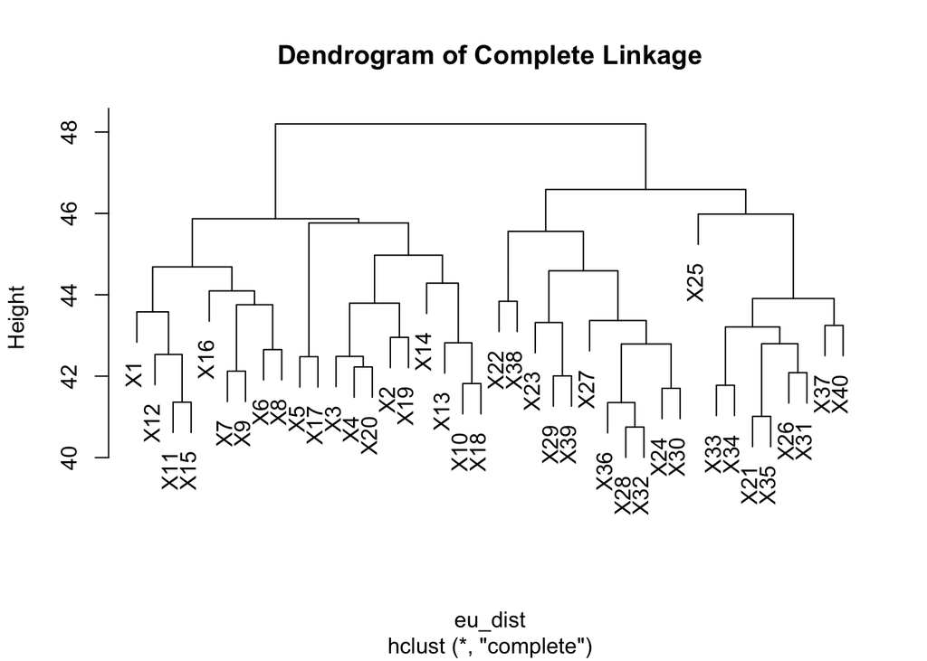

```r
# calculate the complete linkage
hc_complete <- hclust(eu_dist,method = "complete")

# plot the dendrogram for complete linkage
plot(hc_complete, main = "Dendrogram of Complete Linkage")
```

**2.4.2**

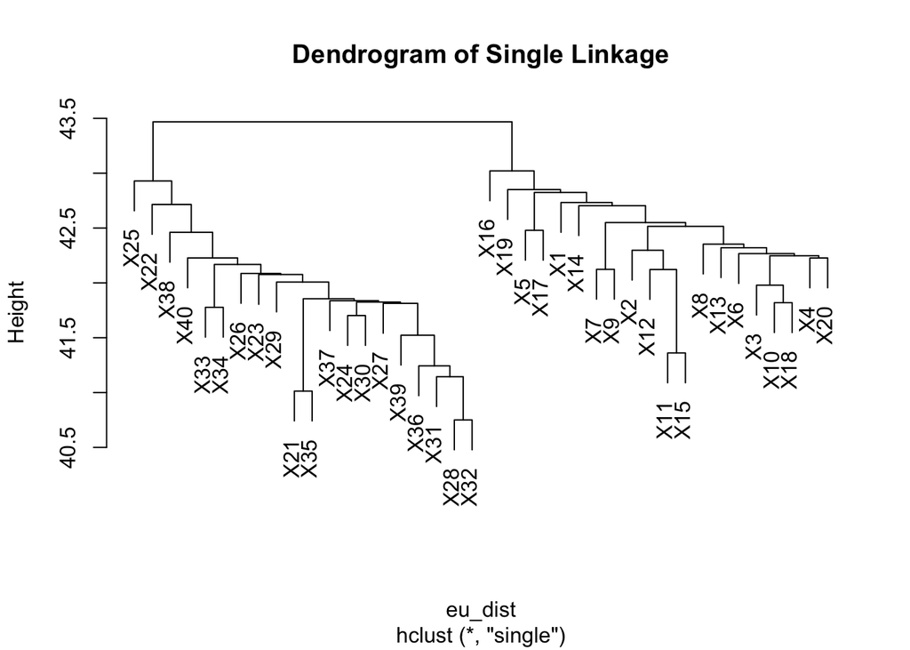

```r
# calculate the single linkage
hc_single <- hclust(eu_dist,method = "single")

# plot the dendrogram for single linkage
plot(hc_single, main = "Dendrogram of Single Linkage")
```

**2.4.3**

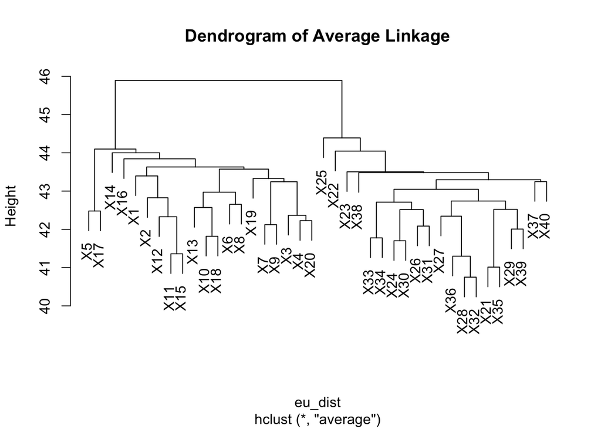

```r
# calculate the average linkage
hc_average <- hclust(eu_dist,method = "average")

# plot the dendrogram for average linkage
plot(hc_average, main = "Dendrogram of Average Linkage")
```

**2.5**

```r
# determine clusters for 2 groups from complete method
clusters_complete <- cutree(hc_complete,k=2)
clusters_complete
```

```
##  X1  X2  X3  X4  X5  X6  X7  X8  X9 X10 X11 X12 X13 X14 X15 X16 X17 X18 X19 X20
##   1   1   1   1   1   1   1   1   1   1   1   1   1   1   1   1   1   1   1   1
## X21 X22 X23 X24 X25 X26 X27 X28 X29 X30 X31 X32 X33 X34 X35 X36 X37 X38 X39 X40
##   2   2   2   2   2   2   2   2   2   2   2   2   2   2   2   2   2   2   2   2
```

```r
# determine clusters for 2 groups from single method
clusters_single <- cutree(hc_single,k=2)
clusters_single
```

```
##  X1  X2  X3  X4  X5  X6  X7  X8  X9 X10 X11 X12 X13 X14 X15 X16 X17 X18 X19 X20
##   1   1   1   1   1   1   1   1   1   1   1   1   1   1   1   1   1   1   1   1
## X21 X22 X23 X24 X25 X26 X27 X28 X29 X30 X31 X32 X33 X34 X35 X36 X37 X38 X39 X40
##   2   2   2   2   2   2   2   2   2   2   2   2   2   2   2   2   2   2   2   2
```

```r
# determine clusters for 2 groups from average method
clusters_average <- cutree(hc_average,k=2)
clusters_average
```

```
##  X1  X2  X3  X4  X5  X6  X7  X8  X9 X10 X11 X12 X13 X14 X15 X16 X17 X18 X19 X20
##   1   1   1   1   1   1   1   1   1   1   1   1   1   1   1   1   1   1   1   1
## X21 X22 X23 X24 X25 X26 X27 X28 X29 X30 X31 X32 X33 X34 X35 X36 X37 X38 X39 X40
##   2   2   2   2   2   2   2   2   2   2   2   2   2   2   2   2   2   2   2   2
```

**2.6**

```r
# create contingency table for complete linkage
table(clusters_complete,status)
```

```
##                  status
## clusters_complete Diseased Healthy
##                 1        0      20
##                 2       20       0
```

```r
# create contingency table for single linkage
table(clusters_single,status)
```

```
##                status
## clusters_single Diseased Healthy
##               1        0      20
##               2       20       0
```

```r
# create contingency table for average linkage
table(clusters_average,status)
```

```
##                 status
## clusters_average Diseased Healthy
##                1        0      20
##                2       20       0
```

## Problem 3

Write a few sentences commenting on the results you obtained in Problems 1 and 2.

### Solution

All three hierarchical clustering linkage methods (complete, single, and average) produced the same clustering results, with 2 clear clusters separating the healthy and diseased groups. The contigency tables for both k-means and hierarchical clustering showed perfect separation - all healthy samples fell into one cluster and diseased into the other. The elbow plot from the k-means clustering showed a clear elbow at k=2 clusters, indicating 2 clusters is the optimal number for this data. This matches what we would expect given there are two known groups. Both k-means clustering and hierarchical clustering showed a clear separation of the data into two distinct clusters that aligned perfectly with disease status. This suggests there are detectable differences in gene expression between the healthy and diseased groups.